# Analyze results from coding for content

Adrienne Marshall

2/9/2018

# Introduction

The goal of this document is to get our data that’s been coded so far. In this case, we’ll split it into only papers that have been coded twice, and see whether the two analyses are different.

`set_1` is a dataframe of each of the papers coded by one person, and `set_2` is the same data frame, with papers coded by the other person. Do we have any apparent systematic bias in who is showing up as a coder in each one?

```
## # A tibble: 6 x 2
## # Groups:   name [6]
##    name     n
##   <chr> <int>
## 1    AM    44
## 2   CMC    43
## 3    DH    34
## 4    MF    42
## 5    PE    47
## 6    SH    32
```

```
## # A tibble: 6 x 2
## # Groups:   name [6]
##    name     n
##   <chr> <int>
## 1    AM    54
## 2   CMC    34
## 3    DH    51
## 4    MF    44
## 5    PE    34
## 6    SH    25
```

# Summary analyses

## Impacts, adaptation, mitigation

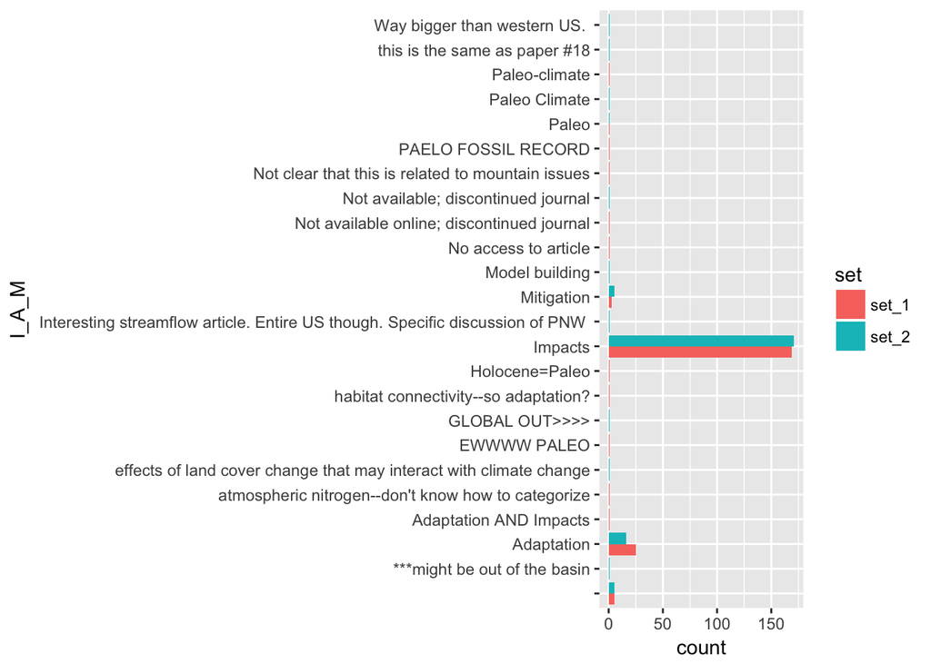

Haha, okay, looks like we should subset to Adaptation, Mitigation, Impacts, “None of these or not in the CRB”, and “other”?

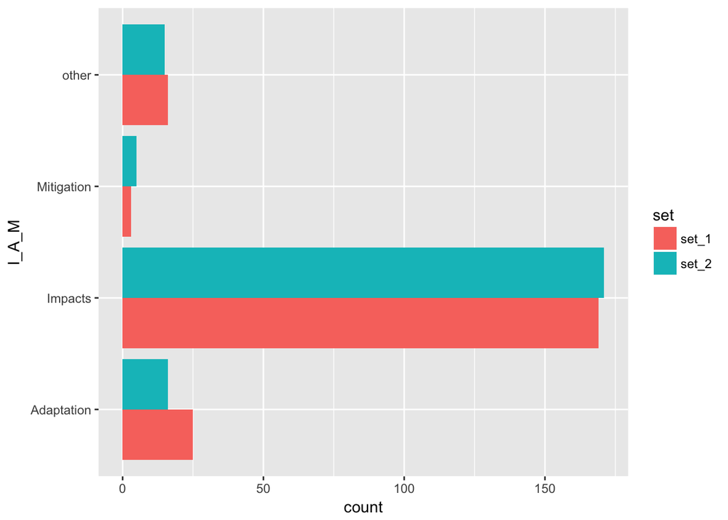

## Impact types

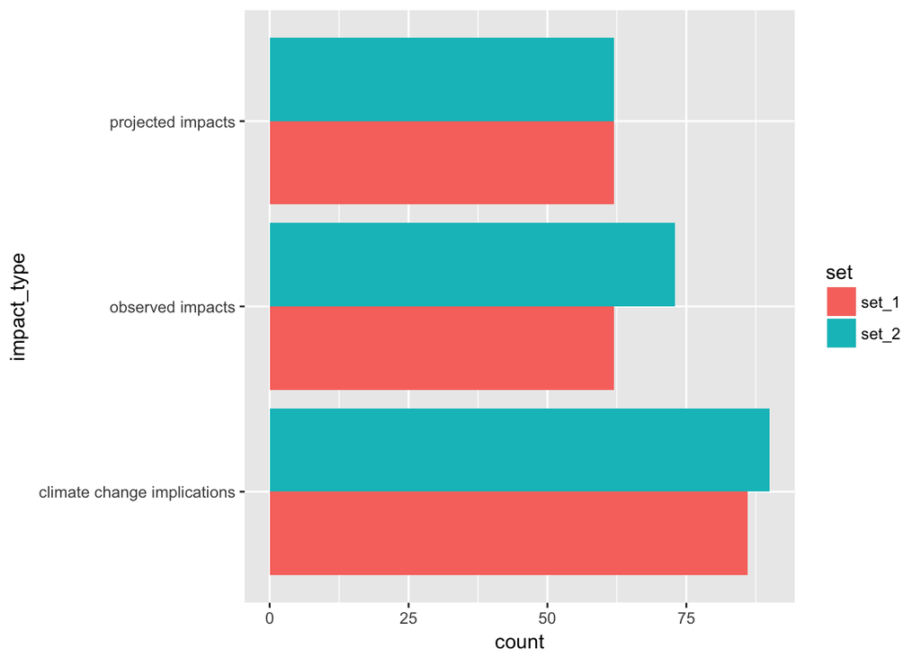

## Resolution

Resolution sort of has too many categories to really view; let’s try this another way.

| resolution | set_1 | set_2 |
| --- | --- | --- |
| Point or plot scale | 137 | 134 |
|  | 17 | 12 |
| >10km2 - 100km2 (smaller than HUC 12) | 12 | 6 |
| 900m2 - 1km2 | 8 | 8 |
| 1-900 m2 (1-30m; Landsat size or smaller) | 7 | 10 |
| >1km2 - 10km2 (city of Moscow is 2.6 km2) | 6 | 10 |
| Western US and/or Western US plus Canada | 3 | 4 |
| 1500 km2 - 25000 km2 (HUC 8 is 1800 km2; Latah County is 2800 km2; 1 degree by 1 degree is also in this category) | 3 | NA |
| Larger than 40,000km2 but less than the Pacific Northwest (e.g., Idaho is 216,000 km2) | 3 | NA |
| 100 km2 - 500 km2 (HUC 12 is 100 km2) | 2 | 3 |
| 25,000 km2 - 40,000km2 (HUC 6 is 27,443 km2) | 2 | 1 |
| No data | 2 | 1 |
| review | 2 | 1 |
| 500 km2 - 1500 km2 (HUC 10 is 587 km2) | 1 | 2 |
| Not clear | 1 | 1 |
| DNA | 1 | NA |
| ecological climate zones of Canada | 1 | NA |
| No data; review | 1 | NA |
| Not specified | 1 | NA |
| Pacific Northwest (e.g., Idaho, Washington, and Oregon) - about HUC 2 size (460,000 km2) | 1 | NA |
| Point or plot scale, 1-900 m2 (1-30m; Landsat size or smaller), Downscales point data | 1 | NA |
| Review | 1 | NA |
| Point or plot scale, 900m2 - 1km2 | NA | 3 |
| 1/8x1/8 degree over the western us | NA | 1 |
| Continental US, possibly exclude | NA | 1 |
| N/A | NA | 1 |
| Not enough information to say | NA | 1 |
| Not stated explicitly; use USFS aerial detection survey | NA | 1 |
| Point or plot scale, 900m2 - 1km2, 5 degree climate data | NA | 1 |
| Point or plot scale, Survey/focus group | NA | 1 |
| Review Paper | NA | 1 |
| Review/Conceptual Modeling | NA | 1 |
| unknown | NA | 1 |
| workshop | NA | 1 |

## Extent

I looked into why so many papers don’t have a resolution; they seem to all be not in the CRB. Let’s do the same thing with extent:

| extent | set_1 | set_2 |
| --- | --- | --- |
| Western US and/or Western US plus Canada | 46 | 43 |
| Larger than 40,000km2 but less than the Pacific Northwest (e.g., Idaho is 216,000 km2) | 40 | 40 |
| 1500 km2 - 25000 km2 (HUC 8 is 1800 km2; Latah County is 2800 km2) | 24 | 23 |
|  | 16 | 13 |
| Pacific Northwest (e.g., Idaho, Washington, and Oregon) - about HUC 2 size (660,000 km2) | 14 | 20 |
| >10km2 - 100km2 (smaller than HUC 12) | 12 | 9 |
| 25,000 km2 - 40,000km2 (HUC 6 is 27,443 km2) | 11 | 9 |
| 100 km2 - 500 km2 (HUC 12 is 100 km2) | 9 | 10 |
| 500 km2 - 1500 km2 (HUC 10 is 587 km2) | 6 | 8 |
| Point or plot scale | 6 | 7 |
| >1km2 - 10km2 (city of Moscow is 2.6 km2) | 5 | 9 |
| 1-900 m2 (1-30m; Landsat size or smaller) | 4 | NA |
| 900m2 - 1km2 | 3 | 2 |
| No data | 2 | NA |
| >10km2 - 100km2 (smaller than HUC 12), 100 km2 - 500 km2 (HUC 12 is 100 km2) | 1 | NA |
| 100 km2 - 500 km2 (HUC 12 is 100 km2), 1500 km2 - 25000 km2 (HUC 8 is 1800 km2; Latah County is 2800 km2), Pacific Northwest (e.g., Idaho, Washington, and Oregon) - about HUC 2 size (660,000 km2), The… | 1 | NA |
| 900m2 - 1km2, 2 study areas both in central Idaho | 1 | NA |
| Continental US | 1 | NA |
| Glaciated area comparison between Rockies and Norway | 1 | NA |
| I am unclear about how to answer this | 1 | NA |
| Many Large Watersheds: Global | 1 | NA |
| Pacific Northwest (e.g., Idaho, Washington, and Oregon) - about HUC 2 size (660,000 km2), Western US and/or Western US plus Canada | 1 | NA |
| Pika range | 1 | NA |
| PNW, BC, Alaska | 1 | NA |
| Unclear: Tetons and Bitterroots | 1 | NA |
| Western Canada only | 1 | NA |
| Western US and/or Western US plus Canada, A little unsure since it is focused on three drainages to three different oceans | 1 | NA |
| Western US and/or Western US plus Canada, south cascade glacier; blue glacier in CRB, many more | 1 | NA |
| Western US and/or Western US plus Canada, Western Canada | 1 | NA |
| 1500 km2 - 25000 km2 (HUC 8 is 1800 km2; Latah County is 2800 km2), 25,000 km2 - 40,000km2 (HUC 6 is 27,443 km2) | NA | 1 |
| a conceptual model? | NA | 1 |
| BC | NA | 1 |
| Continental US. Compares mountainous headwater streams across LTER | NA | 1 |
| Global, with examples in Washington Cascades (BC examples aren’t in CRB) | NA | 1 |
| hard to quantify | NA | 1 |
| Larger than 40,000km2 but less than the Pacific Northwest (e.g., Idaho is 216,000 km2), Pacific Northwest (e.g., Idaho, Washington, and Oregon) - about HUC 2 size (660,000 km2) | NA | 1 |
| Northern Hemisphere | NA | 1 |
| Northern Rocky Mountains | NA | 1 |
| Pacific Northwest (e.g., Idaho, Washington, and Oregon) - about HUC 2 size (660,000 km2), British Columbia | NA | 1 |
| review | NA | 1 |
| Western Canadian Region | NA | 1 |
| Western US and/or Western US plus Canada, mountain pine beetle habitat | NA | 1 |
| Western US and/or Western US plus Canada, Western North America | NA | 1 |

Looks like there are a lot of variable answers here and maybe we need an NA? Let’s take a look in graphical form anyway:

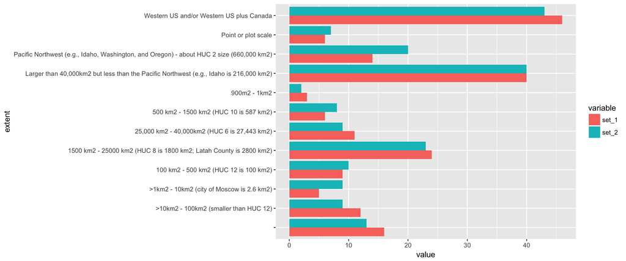

## Location

Let’s start with locations that have a numeric answer. For now, I took out anything that also words in it, even if it has points too. Let’s also subset this to a reasonable spatial extent - currently this is set to less than 1500 km$^2$.

There were also a few points that were way out at sea… so I assume those are mistakes, and got rid of them.

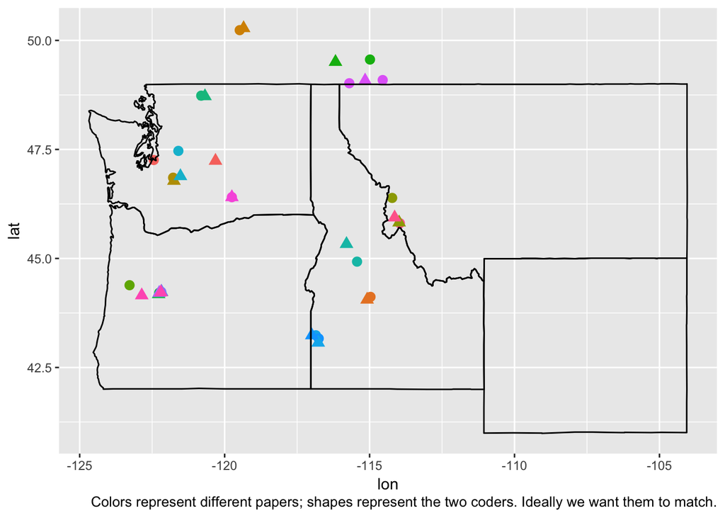

These look pretty good! There aren’t very many papers that are at this smallish scale (less than 1500 km$^2$) that we’ve duplicated observations and have points for… but those that are, look pretty reasonable.

What if we plotted all the locations that have been coded - just to see if we have hotspots showing up?

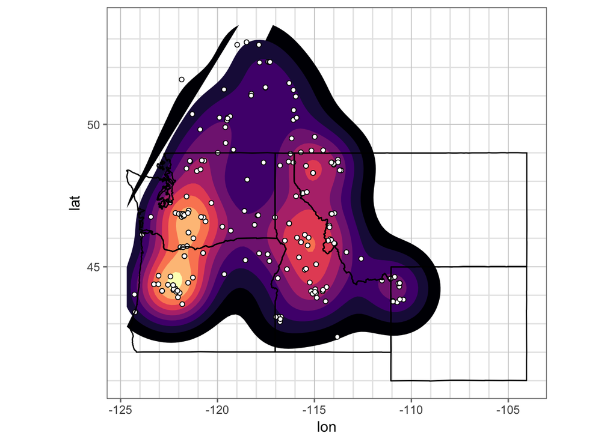

## Biome

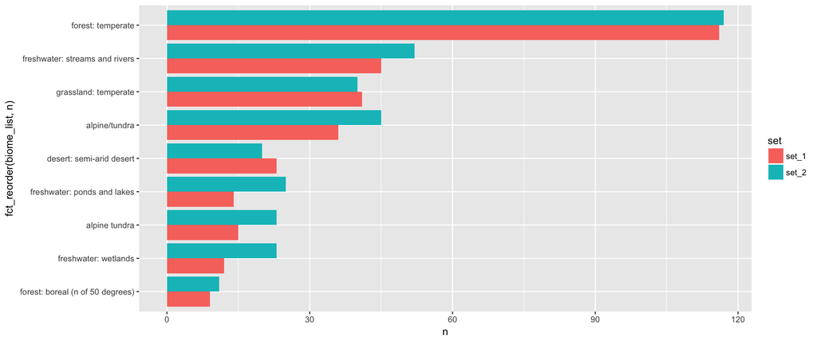

Those differences look like some of the biggest we’ve seen so far… might need to formally test if this is random or not?

## Huc6

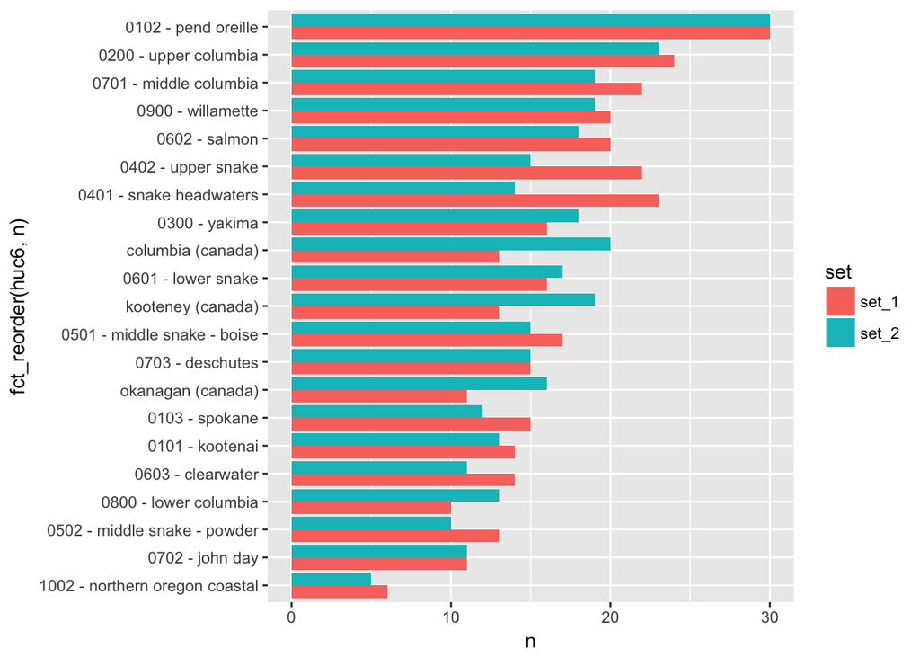

## Data type

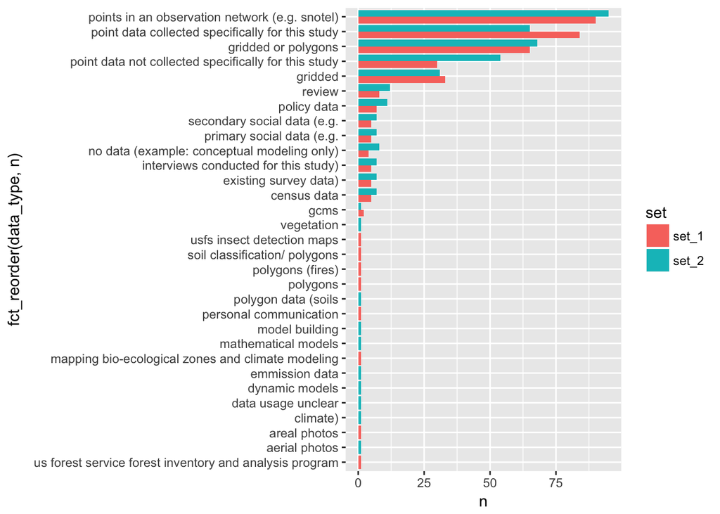

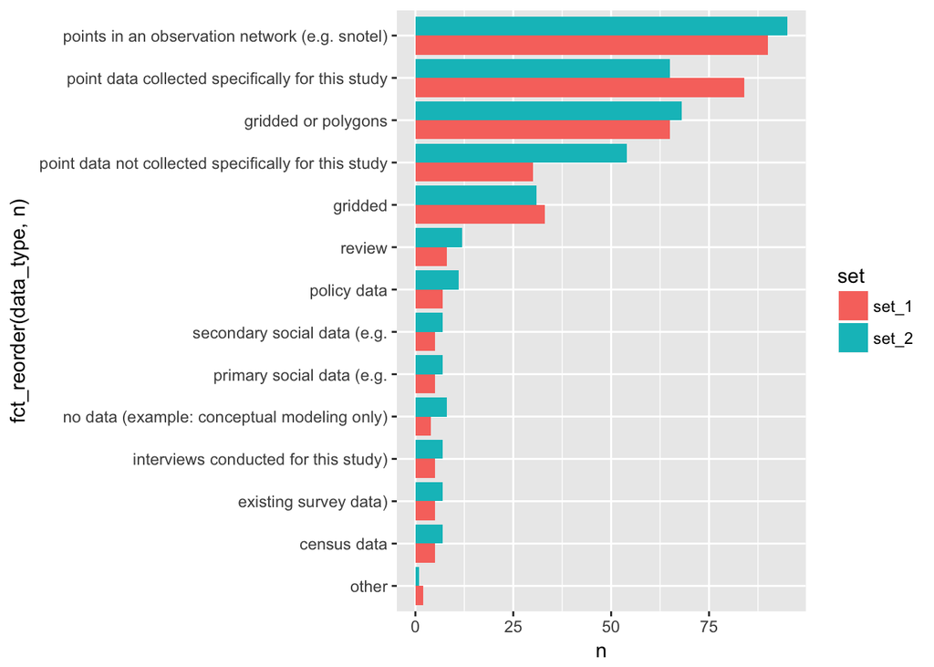

Looks like we have some disagreement about whether point data was or was not collected specifically for a given study… that might be something to address.

## Discipline

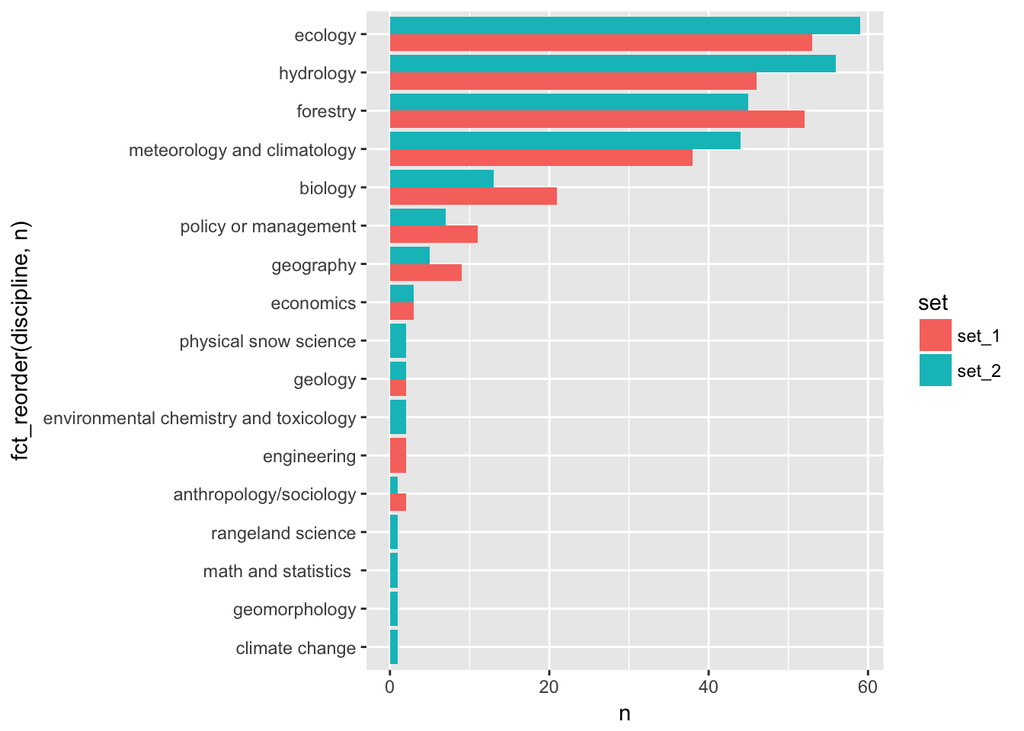

## Topic

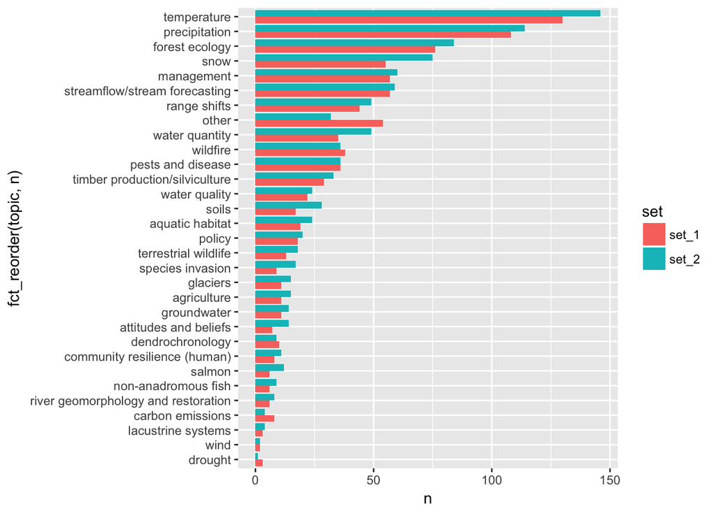

## Topic*Location

How often are different topics studied in different HUCs? Unfortunately, we currently have so many topics and HUCs that this approach doesn’t really work… are there ways we could bin it? Or another way of looking at this that would give us more information?

One thing that might be better is maps - e.g., we could have many small multiples, where in each map, the HUCs are colored by the number of papers for each topic, or relative frequency for that topic?

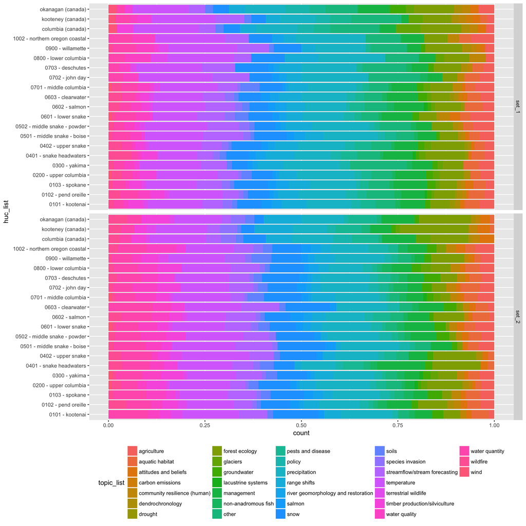

# Extra topics

Make a list of the topics people write in as extra topics. Also, identify items in our list that don’t get used.

# Try mapping HUCs by discipline.

First, take a look at the HUC6 map, just to make sure the spatial data looks good.

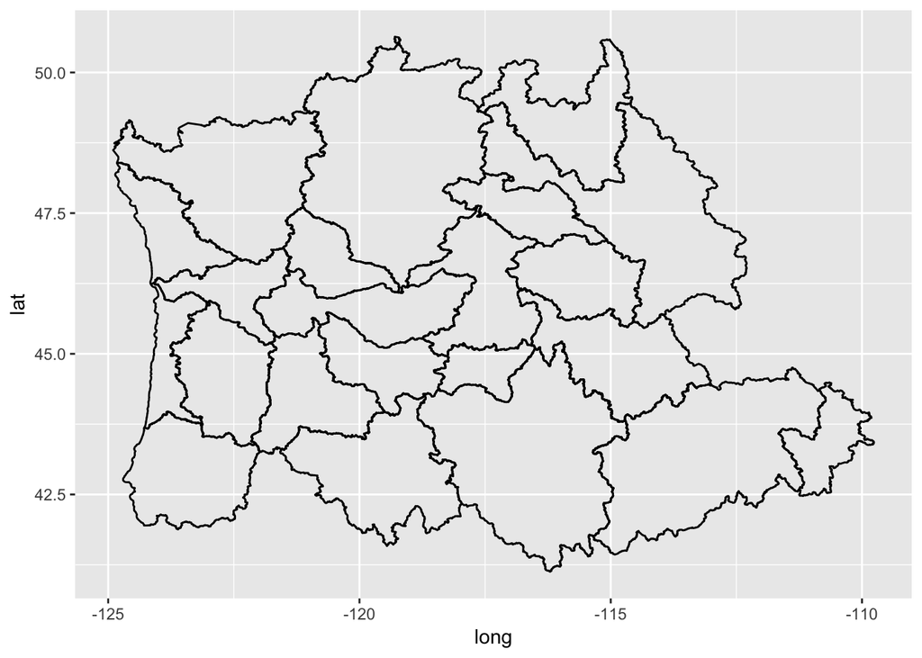